# Modelo predictivo de costos médicos

Joel Ramirez

2025

### CARGA Y PREPARACION DE LOS DATOS

Obtengo el archivo y lo muestro en consola:

```r
df = read.csv("C:/Users/User/OneDrive/Desktop/EJERCICIOS R/ENTREGABLES DEL DIPLO 1/insurance2.csv", sep=",", header = TRUE)
head(df)
```

```
##   age    sex    bmi children smoker    region   charges
## 1  19 female 27.900        0    yes southwest 16884.924
## 2  18   male 33.770        1     no southeast  1725.552
## 3  28   male 33.000        3     no southeast  4449.462
## 4  33   male 22.705        0     no northwest 21984.471
## 5  32   male 28.880        0     no northwest  3866.855
## 6  31 female 25.740        0     no southeast  3756.622
```

#### PREPARACION DE LOS DATOS

Se muestran cuantas filas y columnas hay:

```r
dim(df)
```

```
## [1] 1338    7
```

```r
library(janitor)
df = clean_names(df)
head(df)
```

```
##   age    sex    bmi children smoker    region   charges
## 1  19 female 27.900        0    yes southwest 16884.924
## 2  18   male 33.770        1     no southeast  1725.552
## 3  28   male 33.000        3     no southeast  4449.462
## 4  33   male 22.705        0     no northwest 21984.471
## 5  32   male 28.880        0     no northwest  3866.855
## 6  31 female 25.740        0     no southeast  3756.622
```

Cambio los espacios por guines bajos:

```r
df$smoker = gsub(" ", "_", df$smoker)
df$region = gsub(" ", "_", df$region)
df$sex = gsub(" ", "_", df$sex)
head(df)
```

```
##   age    sex    bmi children smoker    region   charges
## 1  19 female 27.900        0    yes southwest 16884.924
## 2  18   male 33.770        1     no southeast  1725.552
## 3  28   male 33.000        3     no southeast  4449.462
## 4  33   male 22.705        0     no northwest 21984.471
## 5  32   male 28.880        0     no northwest  3866.855
## 6  31 female 25.740        0     no southeast  3756.622
```

VALORES FALTANTES

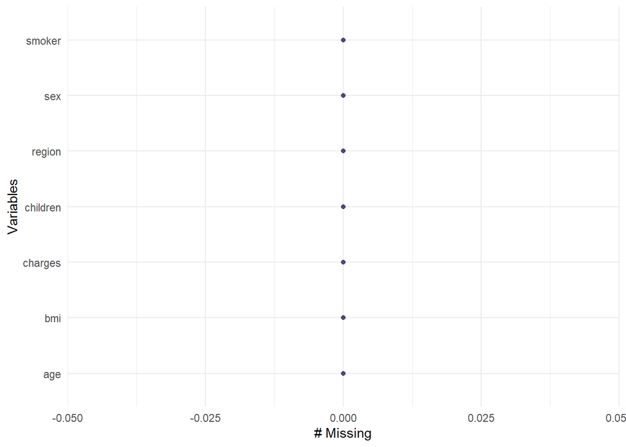

```r
# Instalar naniar
if(!require(naniar)) install.packages("naniar")
library(naniar)

# Visualizar un resumen gráfico de los valores faltantes

gg_miss_var(df)       # Muestra la cantidad de NA por variable
```

Mapa visual de los NA en el dataframe

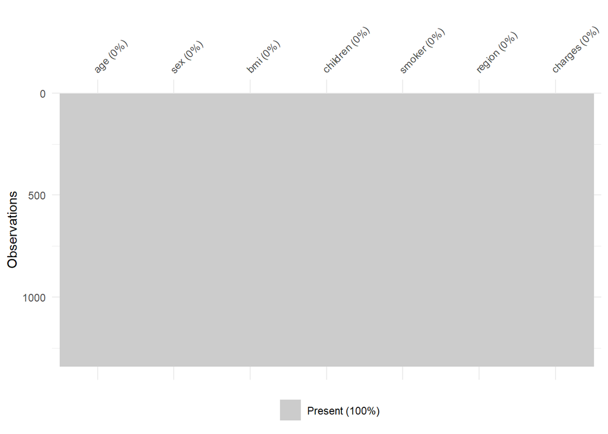

```r
vis_miss(df)
```

Patrones de valores faltantes:

```r
library(VIM)
```

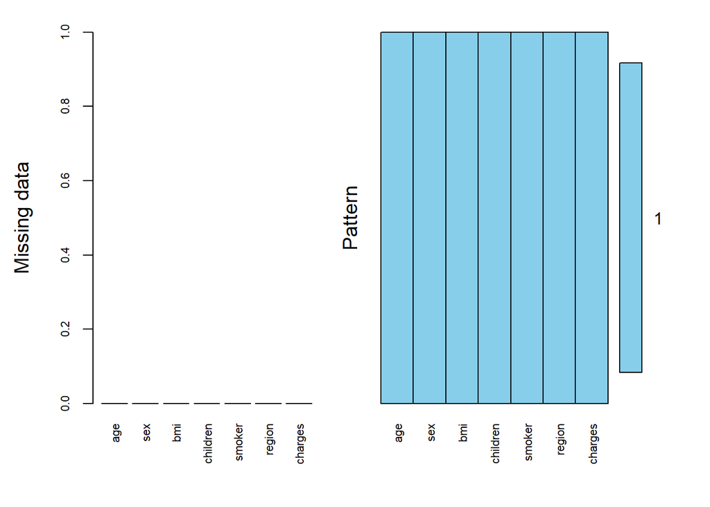

```
##
##  Variables sorted by number of missings:
##  Variable Count
##       age     0
##       sex     0
##       bmi     0
##  children     0
##    smoker     0
##    region     0
##   charges     0
```

```r
aggr(df, numbers=TRUE, sortVars=TRUE, cex.axis=0.7, gap=3, ylab=c("Missing data","Pattern"))
```

### EXPLORACION DE LOS DATOS

Muestro el histograma con base en la variable objetivo

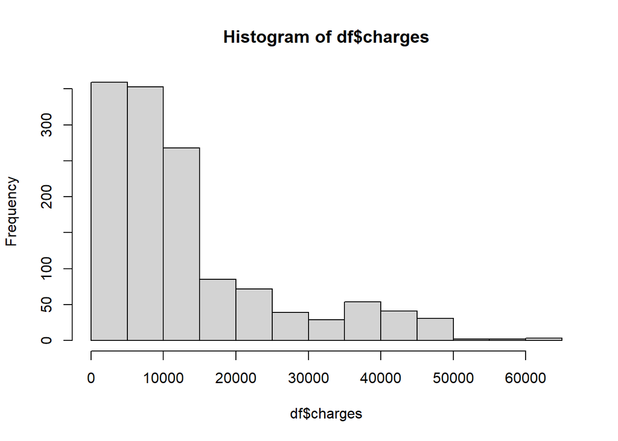

```r
hist(df$charges, freq = TRUE)
```

Muestro el histograma con base en la variable objetivo pero en escala logaritmica:

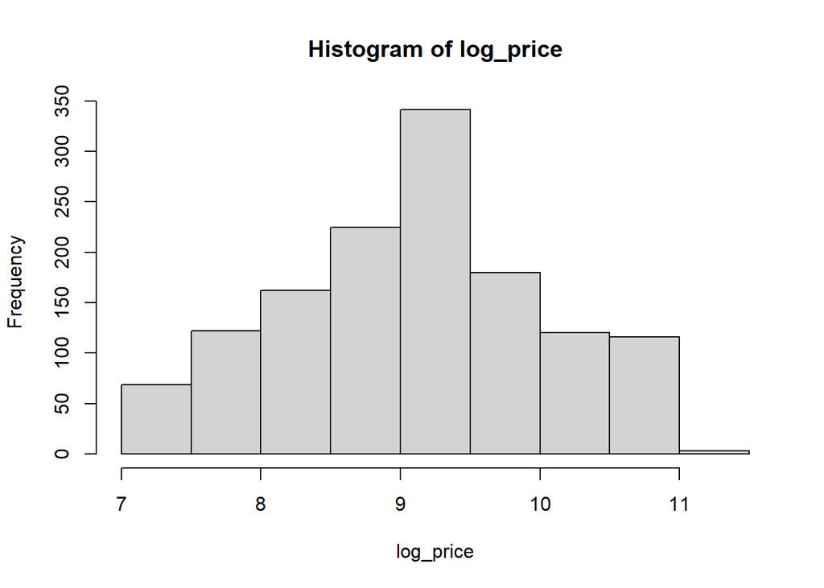

```r
log_price = log1p(df$charges)
hist(log_price, freq = TRUE)
```

#### Correlaciones entre las variables:

Se debe verificar si hay correlaciones entre las variables que no se van a predecir. De ser así, debe salir una de ellas del modelo.

Al aplicar un modelo de regresión múltiple, es fundamental verificar si hay correlaciones significativas entre las variables independientes. Esto se debe a que la multicolinealidad (cuando dos o más variables independientes están altamente correlacionadas) puede afectar la estabilidad y la interpretación del modelo.

```r
df_copia <- data.frame(df)

# Calcular la matriz de correlación

# Convertir variables categóricas a numéricas
df_copia$sex_numeric <- as.numeric(factor(df_copia$sex))
df_copia$smoker_numeric <- as.numeric(factor(df_copia$smoker))
df_copia$region_numeric <- as.numeric(factor(df_copia$region))

# Ahora puedes calcular la matriz de correlación
correlacion_matriz <- cor(df_copia[, c("age", "bmi", "children", "sex_numeric", "smoker_numeric", "region_numeric")])
print(correlacion_matriz)
```

```
##                         age         bmi   children  sex_numeric smoker_numeric
## age             1.000000000 0.109271882 0.04246900 -0.020855872   -0.025018752
## bmi             0.109271882 1.000000000 0.01275890  0.046371151    0.003750426
## children        0.042468999 0.012758901 1.00000000  0.017162978    0.007673120
## sex_numeric    -0.020855872 0.046371151 0.01716298  1.000000000    0.076184817
## smoker_numeric -0.025018752 0.003750426 0.00767312  0.076184817    1.000000000
## region_numeric  0.002127313 0.157565849 0.01656945  0.004588385   -0.002180682
##                region_numeric
## age               0.002127313
## bmi               0.157565849
## children          0.016569446
## sex_numeric       0.004588385
## smoker_numeric   -0.002180682
## region_numeric    1.000000000
```

Visualizar la matriz de correlación

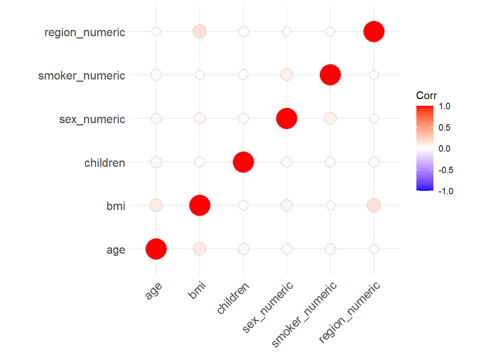

```r
library(ggcorrplot)
ggcorrplot(correlacion_matriz, method = "circle")
```

#### Diferencias, posibles valores atípicos y patrones

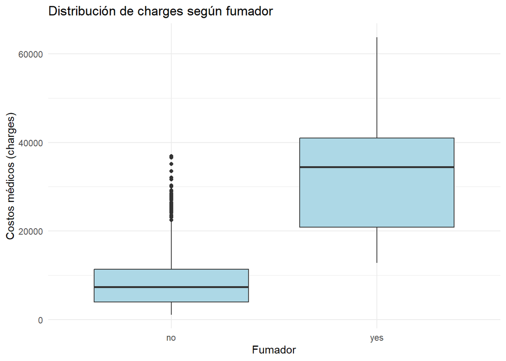

```r
library(ggplot2)

# Boxplot de charges por smoker
ggplot(df, aes(x = smoker, y = charges)) +
  geom_boxplot(fill = "lightblue") +
  labs(title = "Distribución de charges según fumador",
       x = "Fumador",
       y = "Costos médicos (charges)") +
  theme_minimal()
```

Boxplot de charges por región

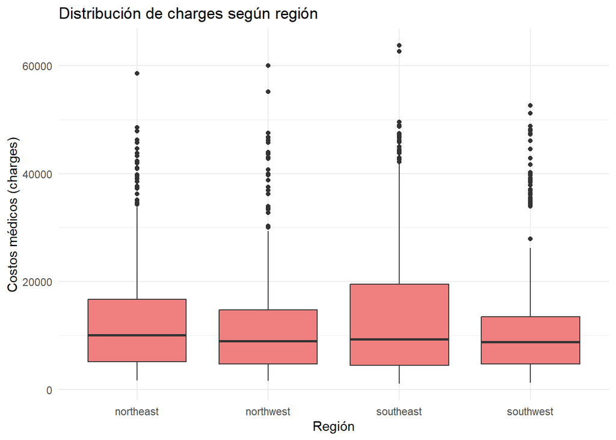

```r
ggplot(df, aes(x = region, y = charges)) +
  geom_boxplot(fill = "lightcoral") +
  labs(title = "Distribución de charges según región",
       x = "Región",
       y = "Costos médicos (charges)") +
  theme_minimal()
```

Boxplot de charges por sexo

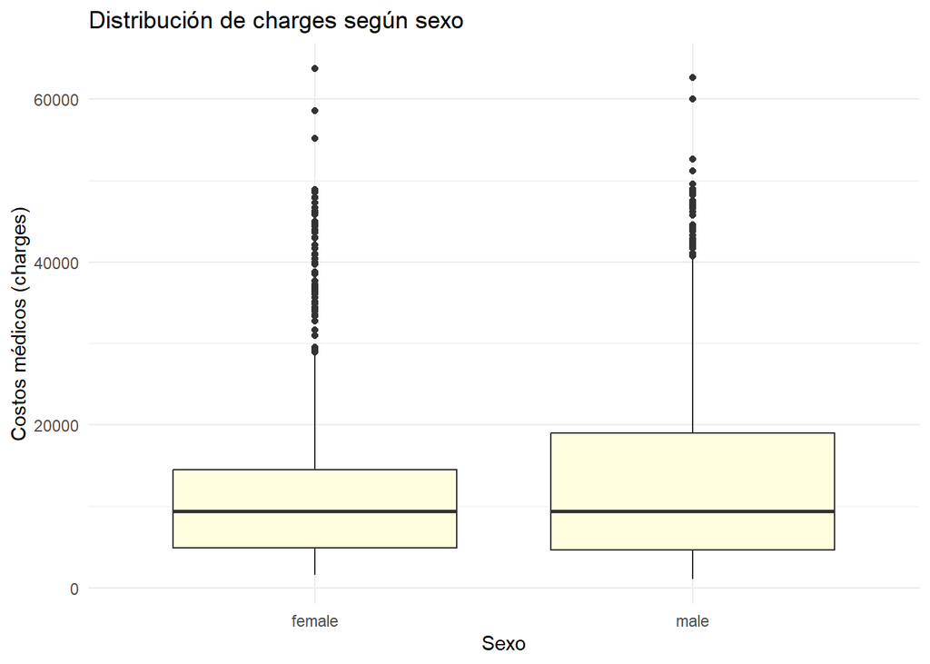

```r
ggplot(df, aes(x = sex, y = charges)) +
  geom_boxplot(fill = "lightyellow") +
  labs(title = "Distribución de charges según sexo",
       x = "Sexo",
       y = "Costos médicos (charges)") +
  theme_minimal()
```

#### Modelo lineal ajustado con la variable objetivo transformada log_charges

```r
# Transformación logarítmica
df$log_charges <- log1p(df$charges)

# Variables categóricas como factores
df$smoker <- as.factor(df$smoker)
df$sex <- as.factor(df$sex)
df$region <- as.factor(df$region)

# Modelo lineal con log_charges
modelo_log <- lm(log_charges ~ age + bmi + children + sex + smoker + region, data = df)
summary(modelo_log)
```

```
##
## Call:
## lm(formula = log_charges ~ age + bmi + children + sex + smoker +
##     region, data = df)
##
## Residuals:
##      Min       1Q   Median       3Q      Max
## -1.07141 -0.19836 -0.04914  0.06601  2.16602
##
## Coefficients:
##                   Estimate Std. Error t value Pr(>|t|)
## (Intercept)      7.0310688  0.0723826  97.138  < 2e-16 ***
## age              0.0345744  0.0008719  39.655  < 2e-16 ***
## bmi              0.0133740  0.0020956   6.382 2.41e-10 ***
## children         0.1018259  0.0100976  10.084  < 2e-16 ***
## sexmale         -0.0753873  0.0243966  -3.090 0.002043 **
## smokeryes        1.5541456  0.0302739  51.336  < 2e-16 ***
## regionnorthwest -0.0637739  0.0348992  -1.827 0.067867 .
## regionsoutheast -0.1571539  0.0350762  -4.480 8.09e-06 ***
## regionsouthwest -0.1289211  0.0350206  -3.681 0.000241 ***
## ---
## Signif. codes:  0 '***' 0.001 '**' 0.01 '*' 0.05 '.' 0.1 ' ' 1
##
## Residual standard error: 0.4442 on 1329 degrees of freedom
## Multiple R-squared:  0.768,  Adjusted R-squared:  0.7666
## F-statistic: 549.8 on 8 and 1329 DF,  p-value: < 2.2e-16
```

**Interpretación de resultados:**

**R-cuadrado ajustado:** 0.7666, lo que indica que aproximadamente el 76.7% de la variabilidad en el logaritmo de charges se explica por las variables del modelo. Esto es un buen ajuste.

**F-statistic:** 549.8 con p-valor < 2.2e-16, indica que el modelo en conjunto es estadísticamente significativo.

**Residuos**

- Los residuales muestran la diferencia entre los valores observados y los predichos.
- Min residual: -1.07, Max residual: 2.17, con mediana cercana a cero, lo que indica que el modelo no tiene sesgo sistemático fuerte.

**Intercepto (7.031):** Valor esperado de log_charges cuando todas las variables predictoras son cero (poco interpretable directamente, pero sirve como base).

**age (0.0346):** Por cada año adicional de edad, el logaritmo de charges aumenta en 0.0346. En términos porcentuales, esto equivale a un aumento aproximado del 3.5% en charges (exp(0.0346) - 1 ≈ 0.035).

**bmi (0.0134):** Por cada unidad adicional en BMI, charges aumentan aproximadamente un 1.3%.

**children (0.1018):** Cada hijo adicional se asocia con un aumento del 10.7% en charges.

**sexmale (-0.0754):** Ser hombre (en comparación con mujer) se asocia con una disminución aproximada del 7.3% en charges.

**regionsoutheast (-0.1572):** Vivir en el sureste se asocia con una disminución del 14.5% en charges, estadísticamente significativo.

**regionsouthwest (-0.1289):** Vivir en el suroeste se asocia con una disminución del 12.1% en charges, también significativo.

**En sintesis:**

- El modelo explica bien la variabilidad en los costos médicos transformados.
- Fumar es el factor con mayor impacto en los costos.
- Edad, BMI y número de hijos también aumentan los costos.
- El sexo masculino parece tener costos ligeramente menores que las mujeres, controlando por otras variables.
- La región geográfica tiene un efecto menor pero presente.

**Graficos**

Tamaño y dirección del efecto de cada variable en el modelo, junto con su incertidumbre

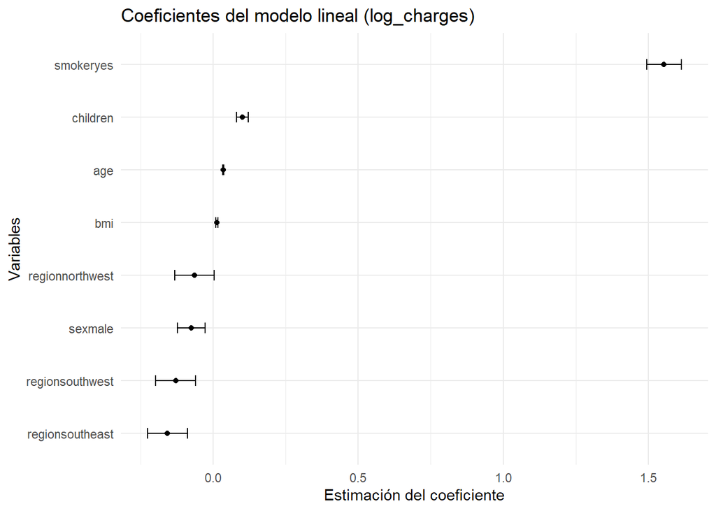

```r
library(ggplot2)
library(broom)

# Extraer coeficientes y errores estándar
coef_df <- broom::tidy(modelo_log)

# Filtrar para evitar el intercepto si quieres
coef_df <- coef_df[coef_df$term != "(Intercept)", ]

# Graficar coeficientes con barras de error (intervalos de confianza aproximados)
ggplot(coef_df, aes(x = reorder(term, estimate), y = estimate)) +
  geom_point() +
  geom_errorbar(aes(ymin = estimate - 1.96*std.error, ymax = estimate + 1.96*std.error), width = 0.2) +
  coord_flip() +
  labs(title = "Coeficientes del modelo lineal (log_charges)",
       x = "Variables",
       y = "Estimación del coeficiente") +
  theme_minimal()
```

Evaluar el ajuste del modelo y detectar patrones en los residuos

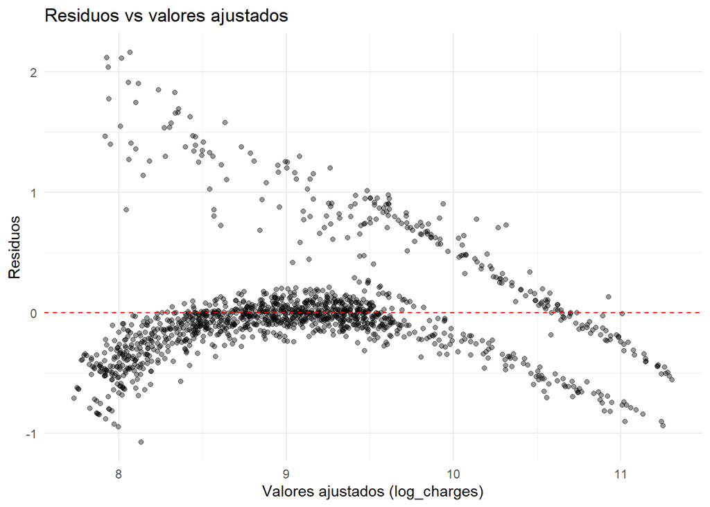

```r
# Obtener valores ajustados y residuos
df$fit <- fitted(modelo_log)
df$residuals <- resid(modelo_log)

ggplot(df, aes(x = fit, y = residuals)) +
  geom_point(alpha = 0.4) +
  geom_hline(yintercept = 0, color = "red", linetype = "dashed") +
  labs(title = "Residuos vs valores ajustados",
       x = "Valores ajustados (log_charges)",
       y = "Residuos") +
  theme_minimal()
```

Predicciones por variable categórica

```r
library(dplyr)
```

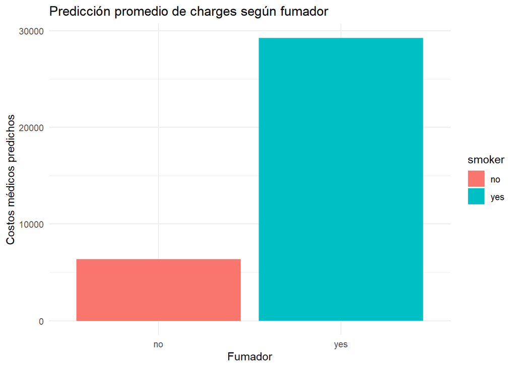

```r
# Crear un nuevo dataframe para predecir manteniendo otras variables constantes
newdata <- df %>%
  group_by(smoker) %>%
  summarise(age = mean(age),
            bmi = mean(bmi),
            children = mean(children),
            sex = "female",
            region = "southeast")

# Predecir log_charges
newdata$pred_log <- predict(modelo_log, newdata = newdata)

# Transformar a escala original
newdata$pred_charges <- expm1(newdata$pred_log)

ggplot(newdata, aes(x = smoker, y = pred_charges, fill = smoker)) +
  geom_col() +
  labs(title = "Predicción promedio de charges según fumador",
       x = "Fumador",
       y = "Costos médicos predichos") +
  theme_minimal()
```

Diagrama de dispersión con línea de regresión para edad y log_charges

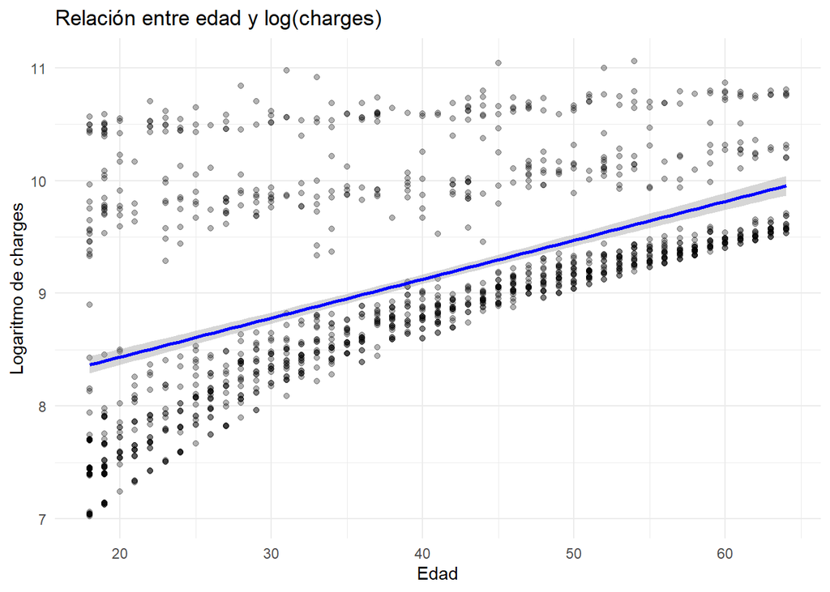

```r
ggplot(df, aes(x = age, y = log_charges)) +
  geom_point(alpha = 0.3) +
  geom_smooth(method = "lm", color = "blue") +
  labs(title = "Relación entre edad y log(charges)",
       x = "Edad",
       y = "Logaritmo de charges") +
  theme_minimal()
```

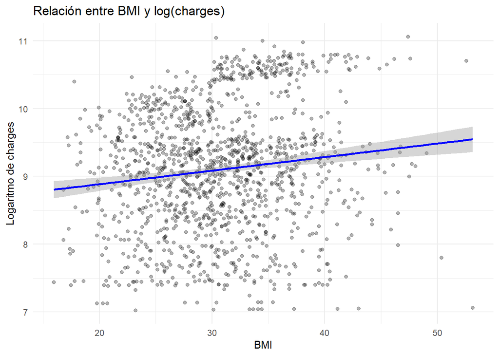

```r
ggplot(df, aes(x = bmi, y = log_charges)) +
  geom_point(alpha = 0.3) +
  geom_smooth(method = "lm", color = "blue") +
  labs(title = "Relación entre BMI y log(charges)",
       x = "BMI",
       y = "Logaritmo de charges") +
  theme_minimal()
```

### Verificación con el modelo robusto con charges originales

```r
library(MASS)
modelo_robusto <- rlm(charges ~ age + bmi + children + sex + smoker + region, data = df)
summary(modelo_robusto)
```

```
##
## Call: rlm(formula = charges ~ age + bmi + children + sex + smoker +
##     region, data = df)
## Residuals:
##      Min       1Q   Median       3Q      Max
## -20231.0   -655.4   -106.7    704.3  25885.6
##
## Coefficients:
##                 Value      Std. Error t value
## (Intercept)     -4952.9268   195.9846   -25.2720
## age               264.6930     2.3607   112.1226
## bmi                60.1649     5.6742    10.6033
## children          444.1961    27.3405    16.2468
## sexmale          -381.6308    66.0568    -5.7773
## smokeryes       30830.8816    81.9701   376.1233
## regionnorthwest  -309.9738    94.4937    -3.2804
## regionsoutheast  -689.2206    94.9731    -7.2570
## regionsouthwest  -664.1531    94.8225    -7.0042
##
## Residual standard error: 994.8 on 1329 degrees of freedom
```

#### Interpretación de resultados:

**Intercepto (-4952.93):** Valor base del costo cuando todas las variables predictoras son cero (poco interpretable directamente, pero sirve como referencia).

**age (264.69):** Por cada año adicional de edad, se espera que los costos médicos aumenten en aproximadamente 265 dólares.

**bmi (60.16):** Por cada unidad adicional en BMI, los costos aumentan en aproximadamente 60 dólares.

**children (444.20):** Cada hijo adicional se asocia con un aumento de aproximadamente 444 dólares en los costos.

**sexmale (-381.63):** Ser hombre (vs mujer) se asocia con una reducción de aproximadamente 382 dólares en los costos médicos.

**smokeryes (30,830.88):** Ser fumador (vs no fumador) se asocia con un aumento enorme en los costos, aproximadamente 30,831 dólares más, confirmando que fumar es el factor más influyente.

**regionsoutheast (-689.22):** Vivir en el sureste se asocia con una reducción de aproximadamente 689 dólares.

**regionsouthwest (-664.15):** Vivir en el suroeste se asocia con una reducción de aproximadamente 664 dólares.

**En resumen**

- El modelo robusto confirma que fumar es el factor que más incrementa los costos médicos, seguido por la edad, BMI y número de hijos.
- El sexo masculino está asociado con costos ligeramente menores.
- La región geográfica tiene un efecto moderado en los costos.
- Este modelo usa los valores originales de charges y es menos sensible a valores atípicos extremos, lo que puede dar predicciones más confiables en presencia de outliers.

### Analisis estadisticos:

- Pruebas de hipótesis para variables categóricas:

Probamos si hay asociación realmente entre el sexo y smoker, sexo y región, region y smoker

##### Sexo y smoker

```r
# Creamos la tabla de contingencia
tabla <- table(df$sex, df$smoker)

# Aplicar prueba Chi-cuadrado
chisq.test(tabla)
```

```
##
##  Pearson's Chi-squared test with Yates' continuity correction
##
## data:  tabla
## X-squared = 7.3929, df = 1, p-value = 0.006548
```

Esto significa que rechazamos la hipótesis nula de que no hay asociación entre las variables sex y smoker. En otras palabras, hay evidencia estadística para afirmar que el sexo y el hábito de fumar están asociados en la muestra.

##### Sexo y región

```r
tabla <- table(df$sex, df$region)

# Aplicar prueba Chi-cuadrado
chisq.test(tabla)
```

```
##
##  Pearson's Chi-squared test
##
## data:  tabla
## X-squared = 0.43514, df = 3, p-value = 0.9329
```

El valor p es muy alto (0.9329), mucho mayor que 0.05. Esto indica que no hay evidencia suficiente para rechazar la hipótesis nula. Por lo tanto, no hay asociación significativa entre el sexo y la región en la muestra. En otras palabras, la distribución de sexos es similar en las diferentes regiones.

##### Región y smoker

```r
tabla <- table(df$smoker, df$region)

# Aplicar prueba Chi-cuadrado
chisq.test(tabla)
```

```
##
##  Pearson's Chi-squared test
##
## data:  tabla
## X-squared = 7.3435, df = 3, p-value = 0.06172
```

El valor p es 0.06172, que es un poco mayor que 0.05, pero cercano. Esto significa que no hay evidencia estadísticamente significativa para afirmar que el hábito de fumar está asociado con la región , aunque está cerca del umbral común de significancia. Podría considerarse una asociación débil o indicativa, pero no concluyente con este nivel de significancia.

#### Relación entre variables cuantitativas

##### age y bmi

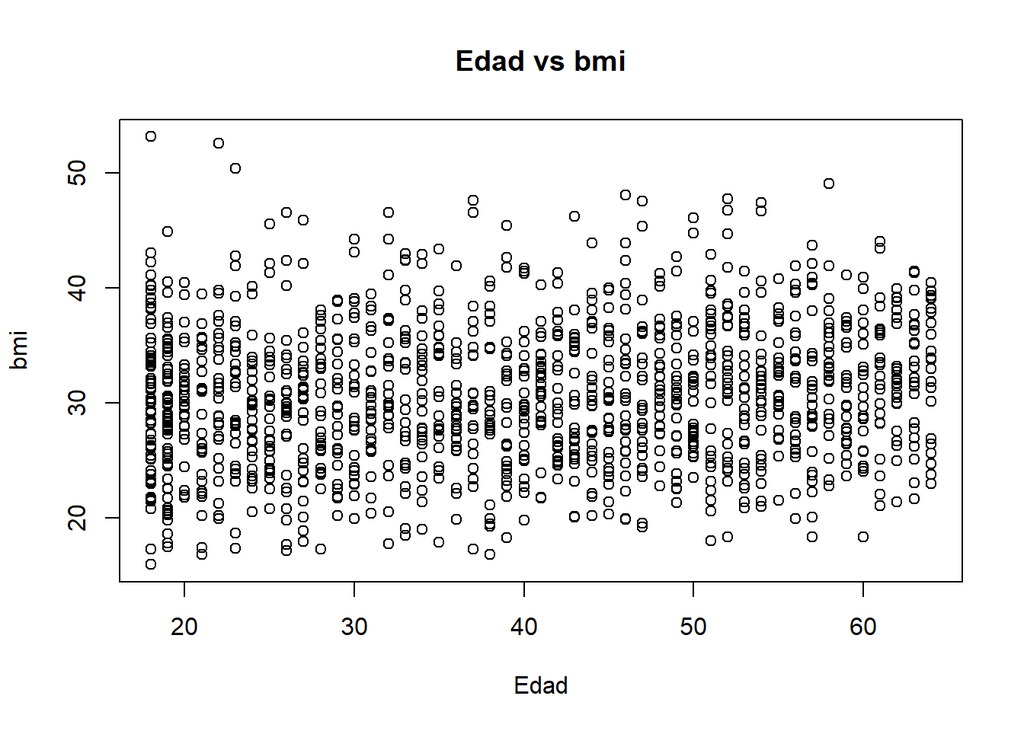

```r
plot(df$age, df$bmi, main="Edad vs bmi", xlab="Edad", ylab="bmi")
```

```r
# Correlación de Pearson
cor.test(df$age, df$bmi, method = "pearson")
```

```
##
##  Pearson's product-moment correlation
##
## data:  df$age and df$bmi
## t = 4.0181, df = 1336, p-value = 6.194e-05
## alternative hypothesis: true correlation is not equal to 0
## 95 percent confidence interval:
##  0.05600895 0.16191463
## sample estimates:
##       cor
## 0.1092719
```

```r
# Si la relación no es lineal o los datos no son normales, Spearman:
cor.test(df$age, df$bmi, method = "spearman")
```

```
##
##  Spearman's rank correlation rho
##
## data:  df$age and df$bmi
## S = 356213358, p-value = 7.859e-05
## alternative hypothesis: true rho is not equal to 0
## sample estimates:
##      rho
## 0.107736
```

##### age y children

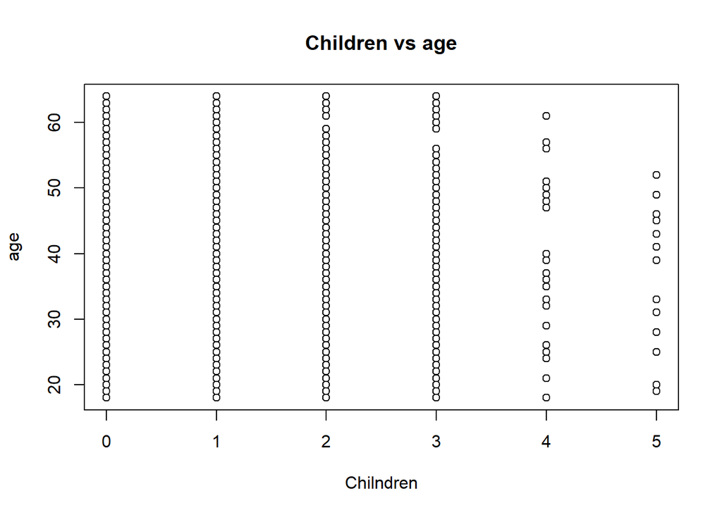

```r
plot(df$children, df$age, main="Children vs age", xlab="Chilndren", ylab="age")
```

```r
# Correlación de Pearson
cor.test(df$age, df$bmi, method = "pearson")
```

```
##
##  Pearson's product-moment correlation
##
## data:  df$age and df$bmi
## t = 4.0181, df = 1336, p-value = 6.194e-05
## alternative hypothesis: true correlation is not equal to 0
## 95 percent confidence interval:
##  0.05600895 0.16191463
## sample estimates:
##       cor
## 0.1092719
```

```r
# Si la relación no es lineal o los datos no son normales, Spearman:
cor.test(df$children, df$age, method = "spearman")
```

```
##
##  Spearman's rank correlation rho
##
## data:  df$children and df$age
## S = 376471515, p-value = 0.03712
## alternative hypothesis: true rho is not equal to 0
## sample estimates:
##        rho
## 0.05699222
```

##### age y charges

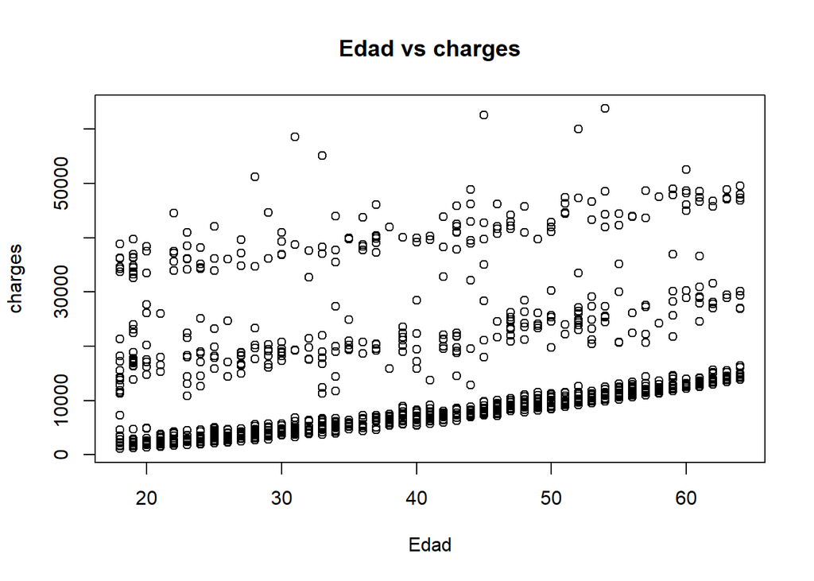

```r
plot(df$age, df$charges, main="Edad vs charges", xlab="Edad", ylab="charges")
```

```r
# Correlación de Pearson
cor.test(df$age, df$charges, method = "pearson")
```

```
##
##  Pearson's product-moment correlation
##
## data:  df$age and df$charges
## t = 11.453, df = 1336, p-value < 2.2e-16
## alternative hypothesis: true correlation is not equal to 0
## 95 percent confidence interval:
##  0.2494139 0.3470381
## sample estimates:
##       cor
## 0.2990082
```

```r
# Si la relación no es lineal o los datos no son normales, Spearman:
cor.test(df$age, df$charges, method = "spearman")
```

```
##
##  Spearman's rank correlation rho
##
## data:  df$age and df$charges
## S = 185881923, p-value < 2.2e-16
## alternative hypothesis: true rho is not equal to 0
## sample estimates:
##       rho
## 0.5343921
```

##### bmi y charges

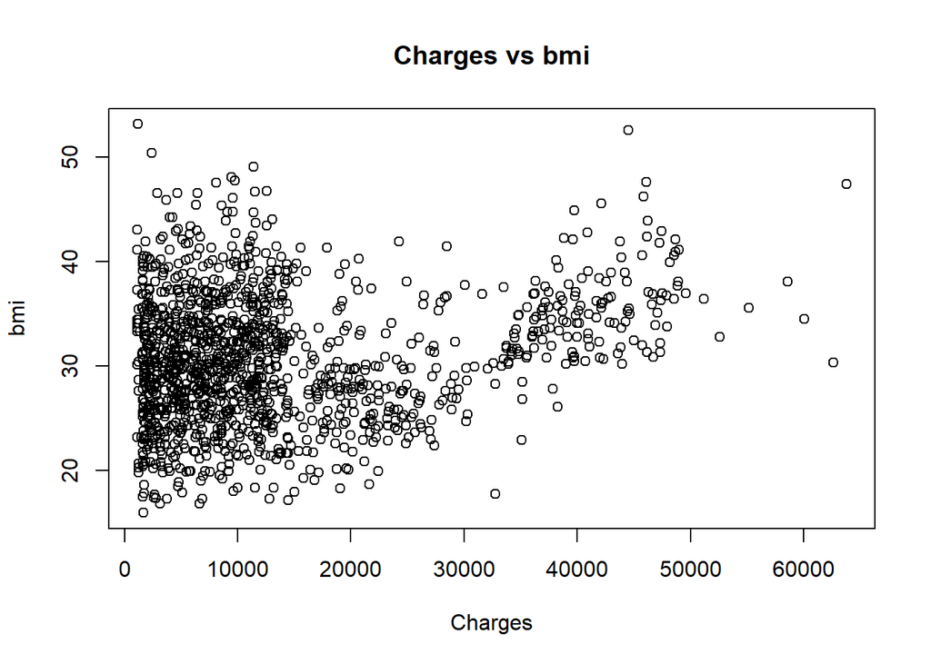

```r
plot(df$charges, df$bmi, main="Charges vs bmi", xlab="Charges", ylab="bmi")
```

```r
# Correlación de Pearson
cor.test(df$charges, df$bmi, method = "pearson")
```

```
##
##  Pearson's product-moment correlation
##
## data:  df$charges and df$bmi
## t = 7.3966, df = 1336, p-value = 2.459e-13
## alternative hypothesis: true correlation is not equal to 0
## 95 percent confidence interval:
##  0.1463052 0.2492822
## sample estimates:
##      cor
## 0.198341
```

```r
# Si la relación no es lineal o los datos no son normales, Spearman:
cor.test(df$charges, df$bmi, method = "spearman")
```

```
##
##  Spearman's rank correlation rho
##
## data:  df$charges and df$bmi
## S = 351558456, p-value = 1.193e-05
## alternative hypothesis: true rho is not equal to 0
## sample estimates:
##       rho
## 0.1193959
```

##### RELACION ENTRE CATEGORICAS Y NUMERICAS

SMOKER VS CHARGES

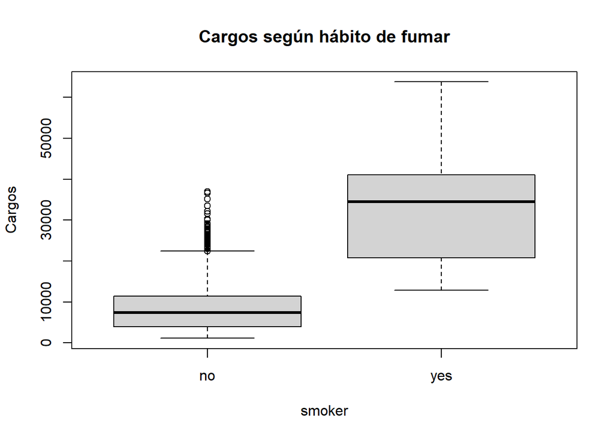

```r
# Boxplot para visualizar
boxplot(charges ~ smoker, data = df, main = "Cargos según hábito de fumar", ylab = "Cargos")
```

```r
# Prueba t para comparar medias
t.test(charges ~ smoker, data = df)
```

```
##
##  Welch Two Sample t-test
##
## data:  charges by smoker
## t = -32.752, df = 311.85, p-value < 2.2e-16
## alternative hypothesis: true difference in means between group no and group yes is not equal to 0
## 95 percent confidence interval:
##  -25034.71 -22197.21
## sample estimates:
##  mean in group no mean in group yes
##          8434.268         32050.232
```

- t = -32.752 Este es el valor del estadístico t, que mide la diferencia entre las medias en unidades de error estándar.
- grados de libertad (df) ≈ 312 Indica la cantidad de información disponible para estimar la variabilidad.
- p-valor < 2.2e-16 Es un valor extremadamente pequeño, mucho menor que 0.05, lo que indica que la diferencia en medias es altamente significativa desde el punto de vista estadístico.
- Intervalo de confianza 95%: (-25034.71, -22197.21) Esto significa que con un 95% de confianza, la diferencia verdadera en las medias de cargos entre no fumadores y fumadores está entre aproximadamente -25,035 y -22,197. Como el intervalo no incluye cero, confirma que la diferencia es significativa.
- Medias por grupo: No fumadores: 8434.27 Fumadores: 32050.23

REGION VS CHARGES

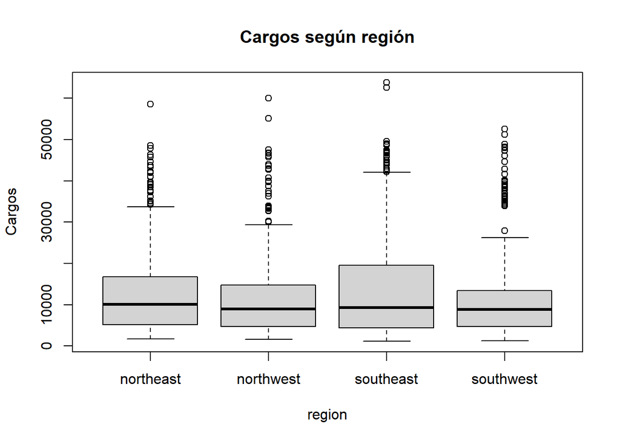

```r
# Boxplot
boxplot(charges ~ region, data = df, main = "Cargos según región", ylab = "Cargos")
```

```r
# ANOVA
anova_result <- aov(charges ~ region, data = df)
summary(anova_result)
```

```
##               Df    Sum Sq   Mean Sq F value Pr(>F)
## region         3 1.301e+09 433586560    2.97 0.0309 *
## Residuals   1334 1.948e+11 146007093
## ---
## Signif. codes:  0 '***' 0.001 '**' 0.01 '*' 0.05 '.' 0.1 ' ' 1
```

- El p-valor es 0.0309, que es menor que 0.05, por lo que rechazamos la hipótesis nula de que las medias de cargos son iguales en todas las regiones.
- Esto indica que existe al menos una diferencia significativa en los cargos promedio entre las regiones.
- El valor F indica que la variabilidad entre grupos (regiones) es mayor que la variabilidad dentro de los grupos, lo que respalda la conclusión de diferencias significativas.

Tuckey para saber donde esta la diferencia:

```r
TukeyHSD(anova_result)
```

```
##   Tukey multiple comparisons of means
##     95% family-wise confidence level
##
## Fit: aov(formula = charges ~ region, data = df)
##
## $region
##                           diff         lwr        upr     p adj
## northwest-northeast  -988.8091 -3428.93434 1451.31605 0.7245243
## southeast-northeast  1329.0269 -1044.94167 3702.99551 0.4745046
## southwest-northeast -1059.4471 -3499.57234 1380.67806 0.6792086
## southeast-northwest  2317.8361   -54.19944 4689.87157 0.0582938
## southwest-northwest   -70.6380 -2508.88256 2367.60656 0.9998516
## southwest-southeast -2388.4741 -4760.50957  -16.43855 0.0476896
```

La única comparación con p-valor ajustado menor a 0.05 es entre southwest y southeast (p = 0.0477), lo que indica que los cargos promedio en la región southwest son significativamente menores que en la región southeast.

- El ANOVA indicó que hay diferencias en cargos entre regiones.
- El test de Tukey muestra que la diferencia significativa está entre las regiones southwest y southeast.
- Las demás regiones no difieren significativamente entre sí en cuanto a cargos promedio.

**Chequeo de multicolinealidad:**

Además de la matriz de correlación, se calcula el VIF (Variance Inflation Factor) para detectar multicolinealidad en variables independientes, que pueden afectar la estabilidad y la interpretación del modelo.

```r
modelo <- lm(charges ~ age + bmi + children + sex + smoker + region, data = df)

library(car)
vif(modelo)
```

```
##              GVIF Df GVIF^(1/(2*Df))
## age      1.016822  1        1.008376
## bmi      1.106630  1        1.051965
## children 1.004011  1        1.002003
## sex      1.008900  1        1.004440
## smoker   1.012074  1        1.006019
## region   1.098893  3        1.015841
```

Todos los valores de VIF están muy cerca de 1, lo que indica ausencia de multicolinealidad problemática entre las variables independientes del modelo.

Esto significa que las variables no están altamente correlacionadas entre sí y que los coeficientes estimados serán estables y confiables.

No se necesita hacer ajustes para multicolinealidad en este caso.

### Aplicacion del modelo predictivo

Los modelos de aprendizaje automático supervisado, suelen mostrar un mejor rendimiento y precisión, por lo que, se usará ello. Al usarlos, se considerará:

- Mantener la transformación logarítmica de charges para manejar la asimetría.

```r
library(caret)
library(glmnet)
library(randomForest)
library(dplyr)

df$log_charges <- log(df$charges)
```

División de los datos:

```r
set.seed(123)
train_index <- createDataPartition(df$log_charges, p = 0.8, list = FALSE)
df_train <- df[train_index, ]
df_test <- df[-train_index, ]
```

Selección de variables con LASSO:

```r
# Preparar matriz de predictores y vector respuesta
x_train <- model.matrix(log_charges ~ age + sex + bmi + children + smoker + region, data = df_train)[, -1]
y_train <- df_train$log_charges

# Ajustar modelo LASSO con validación cruzada
cv_lasso <- cv.glmnet(x_train, y_train, alpha = 1)
best_lambda <- cv_lasso$lambda.min

# Variables seleccionadas (coeficientes no nulos)
coef(cv_lasso, s = best_lambda)
```

```
## 9 x 1 sparse Matrix of class "dgCMatrix"
##                          s1
## (Intercept)      7.06843522
## age              0.03388309
## sexmale         -0.08844087
## bmi              0.01328231
## children         0.09319728
## smokeryes        1.56888948
## regionnorthwest -0.07027397
## regionsoutheast -0.14539149
## regionsouthwest -0.11381627
```

El modelo LASSO seleccionó variables con coeficientes distintos de cero, lo que indica su importancia para predecir log_charges: Variables importantes: age, sexmale, bmi, children, smokeryes, regionnorthwest, regionsoutheast, regionsouthwest.

El intercepto es 7.068.

Esto confirma que el tabaquismo (smokeryes) tiene un gran impacto positivo en los cargos, y que otras variables también aportan, aunque con menor peso.

- Evaluar modelos con validación cruzada para comparar desempeño.

```r
# Control de entrenamiento con validación cruzada 5-fold (por tamaño pequeño de muestra)
train_control <- trainControl(method = "cv", number = 5)

# Entrenar Random Forest para predecir log_charges
set.seed(123)
modelo_rf <- train(log_charges ~ age + sex + bmi + children + smoker + region,
                   data = df_train,
                   method = "rf",
                   trControl = train_control,
                   importance = TRUE)
```

- Al finalizar el modelado, Evaluar sobreajuste con validación cruzada y ajustar hiperparámetros o simplificar el modelo.

```r
# Predicciones en conjunto de prueba
predicciones <- predict(modelo_rf, newdata = df_test)

# Métricas de desempeño
postResample(pred = predicciones, obs = df_test$log_charges)
```

```
##      RMSE  Rsquared       MAE
## 0.3851619 0.8230078 0.2141358
```

Métricas en el conjunto de prueba:

- RMSE: 0.385 — error promedio en la escala logarítmica, relativamente bajo.
- R²: 0.82 — el modelo explica aproximadamente el 82% de la variabilidad en log_charges.
- MAE: 0.214 — error absoluto medio, también bajo. Estos valores indican un buen desempeño del modelo

Visualización con los factores mas importantes.

```r
varImp(modelo_rf)
```

```
## rf variable importance
##
##                  Overall
## smokeryes       100.0000
## age              83.7040
## bmi              13.8833
## children         13.5230
## sexmale           2.8377
## regionsoutheast   2.0862
## regionnorthwest   0.4102
## regionsouthwest   0.0000
```

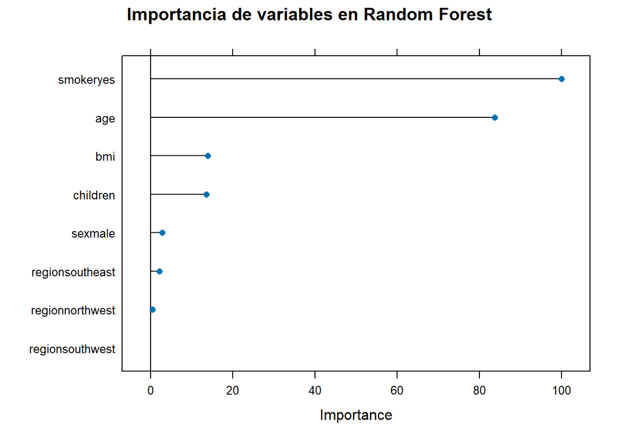

```r
plot(varImp(modelo_rf), main = "Importancia de variables en Random Forest")
```

#### Probamos el modelo:

```r
nuevo_dato <- data.frame(
  age = 62,
  sex = factor("female", levels = levels(df$sex)),
  bmi = 26.290,
  children = 0,
  smoker = factor("yes", levels = levels(df$smoker)),
  region = factor("southeast", levels = levels(df$region))
)

prediccion_log <- predict(modelo_rf, newdata = nuevo_dato)

prediccion_charges <- exp(prediccion_log)
print(prediccion_charges)
```

```
##        1
## 27774.99
```

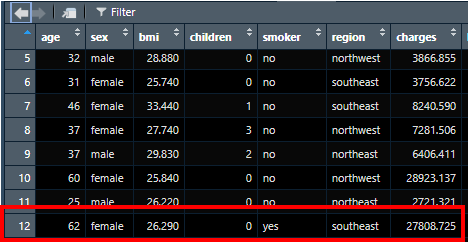

Resultado esperado

#### Segunda prueba:

```r
nuevo_dato <- data.frame(
  age = 24,
  sex = factor("female", levels = levels(df$sex)),
  bmi = 26.600,
  children = 0,
  smoker = factor("no", levels = levels(df$smoker)),
  region = factor("northeast", levels = levels(df$region))
)

prediccion_log <- predict(modelo_rf, newdata = nuevo_dato)

prediccion_charges <- exp(prediccion_log)
print(prediccion_charges)
```

```
##        1
## 4004.757
```

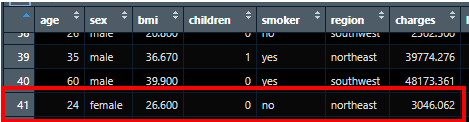

#### Tercera prueba:

```r
nuevo_dato <- data.frame(
  age = 38,
  sex = factor("male", levels = levels(df$sex)),
  bmi = 37.050,
  children = 1,
  smoker = factor("no", levels = levels(df$smoker)),
  region = factor("northeast", levels = levels(df$region))
)

prediccion_log <- predict(modelo_rf, newdata = nuevo_dato)

prediccion_charges <- exp(prediccion_log)
print(prediccion_charges)
```

```
##        1
## 6272.844
```

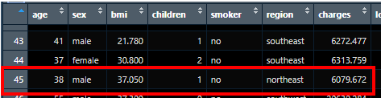

Resultado esperado

### Conclusiones

- El modelo LASSO seleccionó variables con coeficientes distintos de cero, lo que indica su importancia para predecir log_charges: Variables importantes: age, sexmale, bmi, children, smokeryes, regionnorthwest, regionsoutheast, regionsouthwest.
- El tabaquismo (smokeryes) tiene un gran impacto positivo en los cargos, y que otras variables también aportan, aunque con menor peso.
- El RMSE resultó ser 0.385, siendo un error promedio en la escala logarítmica, relativamente bajo, por lo que, brinda credibilidad al modelo.
- El R² resultó ser de 0.82, lo cual quiere decir que el modelo explica aproximadamente el 82% de la variabilidad en log_charges.
- El MAE mostró un valor de 0.214 (error absoluto medio), también bajo. Estos valores indican un buen desempeño del modelo, por lo que, el valor aal predecir estará dentro de ese porcentaje de error absoluto.